# First-pass analyses

[Guillermo Montero-Melis](https://www.mpi.nl/people/montero-melis-guillermo)

05/09/2019

# 1 Introduction

Carry out a first-pass analysis of the data in Petrus I.’s bachelor thesis to see if it is suitable to be written up as a study and submitted to a journal.

Remarks:

- The data has been pre-processed in a separate script (`data/process_data.Rmd`)
- I will mostly try to replicate the analyses in Petrus’s BA thesis with a few extensions; this means I largely follow the order of how the results are reported in that thesis

# 2 Set up workspace

## 2.1 Libraries

```r
knitr::opts_chunk$set(echo = TRUE)
library(knitr)
library(dplyr)
library(ggplot2)
library(GGally)
library(tidyr)
library(lme4)
```

## 2.2 Data

Matching task:

```r
# Matching task
d_match <- read.csv("../data/data_matching-task.csv", fileEncoding = "UTF-8")
head(d_match)
```

```
##   Subject                 ImageFile Score KeyPress CorrKey   TargetWord
## 1       1  pict_lang_test/bild4.png     1        j       j         comb
## 2       1 pict_lang_test/bild10.png     1        q       q         lamp
## 3       1  pict_lang_test/bild6.png     1        d       d bowling ball
## 4       1 pict_lang_test/bild14.png     1        4       4       violin
## 5       1 pict_lang_test/bild30.png     1        a       a        apple
## 6       1 pict_lang_test/bild23.png     1        s       s    paint can
```

Form/category task:

```r
# form/category task -- two versions to choose from (uncomment/comment one)

# # full version
# d_fc <- read.csv("../data/data_form-category-task.csv", fileEncoding = "UTF-8")

# cleaned version (see "~/data/process_data.Rmd" for details)
d_fc <- read.csv("../data/data_form-category-task_cleaned.csv", fileEncoding = "UTF-8")

head(d_fc)
```

```
##   Subject  Task Language Trial Score ItemID Comment
## 1       1 Shape       L1     1     1     22
## 2       1 Shape       L1     2     1     17
## 3       1 Shape       L1     3     1      6
## 4       1 Shape       L1     4     1     16
## 5       1 Shape       L1     5     1      7
## 6       1 Shape       L1     6     1     15
##                                 Descr LangOrder
## 1         1. timglas 2. piano 3. fiol     L2-L1
## 2     1. målarpensel 2. flöjt 3. fiol     L2-L1
## 3      1. klarinett 2. päron 3. banan     L2-L1
## 4 1. färgburk 2. målarpensel 3. banan     L2-L1
## 5      1. flöjt 2. färgburk 3. trumma     L2-L1
## 6  1. lampa 2. ficklampa 3. klarinett     L2-L1
```

Participant background data, including L2 English proficiency (LexTale):

```r
backgr <- read.csv("../data/participant-background.csv", fileEncoding = "UTF-8")
head(backgr)
```

```
##   Subject Age Sex L2_start L2_self Months_L2_country LexTale
## 1       1  38 man        9       5                 0  0.9375
## 2       2  45 man       10       1                 1  0.6125
## 3       3  37 man        7       5                 1  0.8875
## 4       4  33 man        6       7                 1  1.0000
## 5       5  33 man        7       4                 3  0.7000
## 6       6  29 man        9       5                 2  0.8000
```

Inference task:

```r
d_infe <- read.csv("../data/data_inference-task.csv", fileEncoding = "UTF-8",
                   stringsAsFactors = FALSE)
# Want to change "visuospatial" to "spatial" for clarity
d_infe$Type[d_infe$Type == "Visuospatial"] <- "Spatial"
head(d_infe)
```

```
##   Subject Language          Item Trial Score        RT
## 1       1       L1  audio/n7.wav     1     0 2.6119200
## 2       1       L1 audio/n20.wav     2     1 1.0598361
## 3       1       L1 audio/n22.wav     3     1 0.5754024
## 4       1       L1 audio/n17.wav     4     1 0.2093123
## 5       1       L1 audio/n24.wav     5     1 0.3090446
## 6       1       L1 audio/n10.wav     6     1 0.2569126
##                   InferPattern    Type Valid
## 1 1) A-r-B; 2) C-R-B; 3) A-r-C Control     1
## 2 1) B-r-A; 2) C-R-A; 3) B-r-C Control     1
## 3 1) B-r-A; 2) C-R-A; 3) B-r-C Spatial     1
## 4 1) B-r-C; 2) B-R-A; 3) C-r-A Control     0
## 5 1) B-r-C; 2) B-R-A; 3) C-r-A Spatial     0
## 6 1) A-r-B; 2) C-R-B; 3) A-r-C  Visual     1
##                                                  Description
## 1  1) ape-dumber-dog; 2) cat-smarter-dog; 3) ape-dumber-cat?
## 2     1) dog-worse-ape; 2) cat-better-ape; 3) dog-worse-cat?
## 3      1) dog-below-ape; 2) cat-above-ape; 3) dog-below-cat?
## 4     1) dog-worse-cat; 2) dog-better-ape; 3) cat-worse-ape?
## 5      1) dog-below-cat; 2) dog-above-ape; 3) cat-below-ape?
## 6 1) ape-thinner-dog; 2) cat-fatter-dog; 3) ape-thinner-cat?
```

# 3 Matching task

The matching task was used to exclude items in the form/category task for those participants who could not match it correctly (assuming that their performance on such an item is uninformative if they don’t know the meaning of the word).

*NB*: This resulted in the “cleaned” dataset for the form/category task (see Data above).

```r
head(d_match)
```

```
##   Subject                 ImageFile Score KeyPress CorrKey   TargetWord
## 1       1  pict_lang_test/bild4.png     1        j       j         comb
## 2       1 pict_lang_test/bild10.png     1        q       q         lamp
## 3       1  pict_lang_test/bild6.png     1        d       d bowling ball
## 4       1 pict_lang_test/bild14.png     1        4       4       violin
## 5       1 pict_lang_test/bild30.png     1        a       a        apple
## 6       1 pict_lang_test/bild23.png     1        s       s    paint can
```

How accurate were subjects on this task?

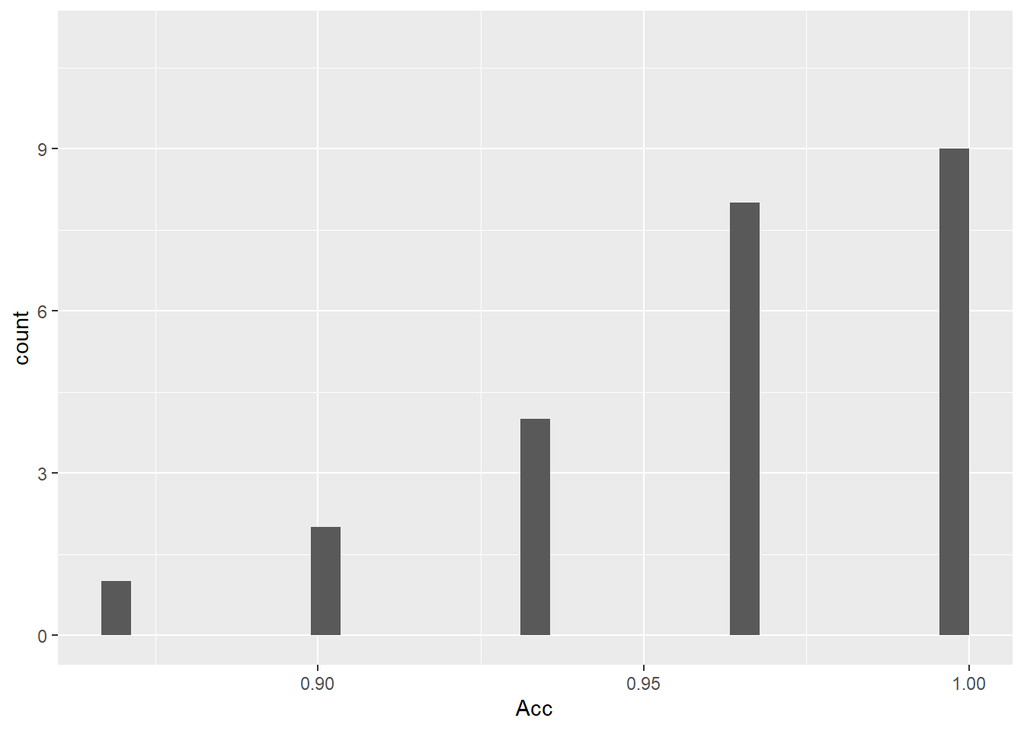

```r
d_match %>% group_by(Subject) %>% summarise(Acc = mean(Score)) %>%
  ggplot(aes(x = Acc)) + geom_histogram() + ylim(0, 11)
```

We see that most were quite accurate.

Another way to see that is to account the number of errors

```r
d_match$Error <- ifelse(d_match$Score == 1, 0, 1)
d_match %>% group_by(Subject) %>%
  summarise(NbErrors = sum(Error)) %>%
  group_by(NbErrors) %>%
  summarise(Freq = n()) %>%
  kable
```

| NbErrors | Freq |
| --- | --- |
| 0 | 9 |
| 1 | 8 |
| 2 | 4 |
| 3 | 2 |
| 4 | 1 |

Let’s look at it from the point of view of the items:

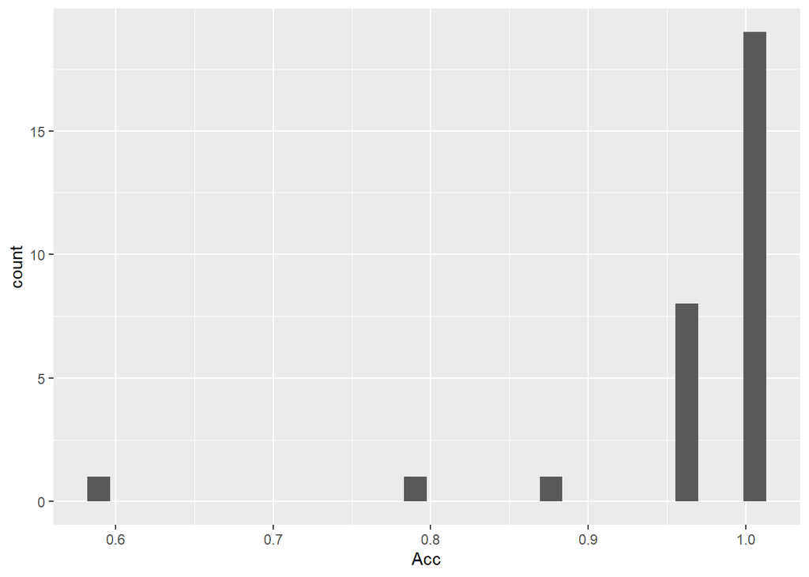

```r
d_match %>% group_by(TargetWord) %>% summarise(Acc = mean(Score)) %>%
  ggplot(aes(x = Acc)) + geom_histogram()
```

There were some items that elicited a large number of errors, especially “hairspray”:

```r
d_match %>% group_by(TargetWord) %>%
  summarise(NbErrors = sum(Error)) %>%
  arrange(- NbErrors) %>%
  print(n = 12)
```

```
## # A tibble: 30 x 2
##    TargetWord     NbErrors
##    <fct>             <dbl>
##  1 hairspray            10
##  2 flute                 5
##  3 clarinet              3
##  4 button                1
##  5 coconut               1
##  6 cucumber slice        1
##  7 orange                1
##  8 paint brush           1
##  9 paint can             1
## 10 soda can              1
## 11 toast                 1
## 12 apple                 0
## # ... with 18 more rows
```

# 4 Form- and category tasks

## 4.1 By-subject visualization

Summarize each participant’s data as a single number, namely their mean accuracy (`Acc`) in each task and language:

```r
d_fc_subj <- d_fc %>%
  group_by(Subject, Task, Language) %>%
  summarise(Acc = mean(Score))
```

Identify outliers (wrt to Tukey/ggplot2 boxplots):

```r
d_fc_subj <- d_fc %>%
  group_by(Subject, Task, Language) %>%
  summarise(Acc = mean(Score))

# To be able to plot the label names of outliers (SPSS does it by default), we
# adapt the solution proposed in
# https://stackoverflow.com/questions/33524669/labeling-outliers-of-boxplots-in-r
is_outlier <- function(x) {
  return(x < quantile(x, 0.25) - 1.5 * IQR(x) | x > quantile(x, 0.75) + 1.5 * IQR(x))
}
# Outlier contains a subject ID if they are an outlier for a task-language combo
d_fc_subj <- d_fc_subj %>%
  group_by(Task, Language) %>%
  mutate(Outlier = ifelse(is_outlier(Acc), Subject, as.numeric(NA)))
head(d_fc_subj)
```

```
## # A tibble: 6 x 5
## # Groups:   Task, Language [4]
##   Subject Task     Language   Acc Outlier
##     <int> <fct>    <fct>    <dbl>   <dbl>
## 1       1 Category L1           1      NA
## 2       1 Category L2           1      NA
## 3       1 Shape    L1           1      NA
## 4       1 Shape    L2           1      NA
## 5       2 Category L1           1      NA
## 6       2 Category L2           1      NA
```

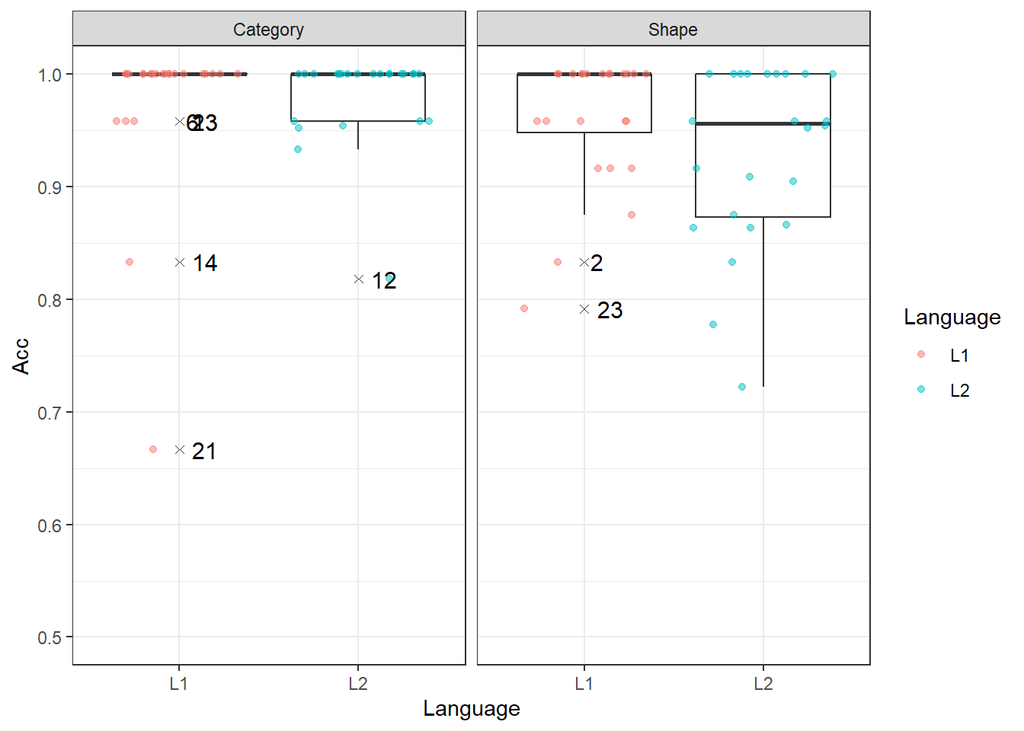

```r
ggplot(d_fc_subj, aes(x = Language, y = Acc)) +
  geom_boxplot(outlier.shape = 4) +
  geom_jitter(height = 0, alpha = .5, aes(colour = Language)) +
  geom_text(aes(label = Outlier), na.rm = TRUE, hjust = -0.5, size = 4) +
  facet_grid(. ~ Task) +
  ylim(.5, 1) +
  theme_bw()
```

## 4.2 By-item visualization

Summarize the data by items instead (but otherwise analogously as above):

```r
d_fc_item <- d_fc %>%
  group_by(ItemID, Task, Language) %>%
  summarise(Acc = mean(Score))
head(d_fc_item)
```

```
## # A tibble: 6 x 4
## # Groups:   ItemID, Task [3]
##   ItemID Task     Language   Acc
##    <int> <fct>    <fct>    <dbl>
## 1      0 Category L1       1
## 2      0 Category L2       0.957
## 3      0 Shape    L1       1
## 4      0 Shape    L2       1
## 5      1 Category L1       1
## 6      1 Category L2       1
```

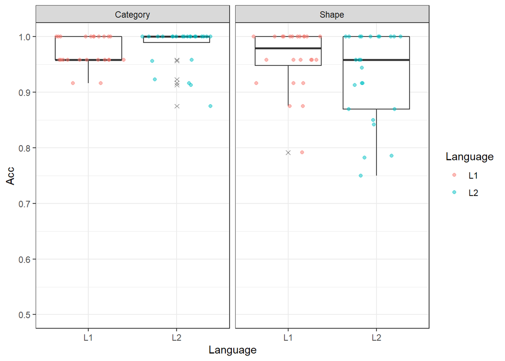

```r
ggplot(d_fc_item, aes(x = Language, y = Acc)) +
  geom_boxplot(outlier.shape = 4) +
  geom_jitter(height = 0, alpha = .5, aes(colour = Language)) +
  facet_grid(. ~ Task) +
  ylim(.5, 1) +
  theme_bw()
```

## 4.3 Generalized Linear Mixed Model (GLMM) analysis

The hypothesis is that there should be an interaction between language and task, such that participants perform worse in the shape task when carrying it out in the L2, but their performance should not be worse in the category task.

```r
# Sum coding for factors
# Task
contrasts(d_fc$Task) <- contr.sum(2)
colnames(contrasts(d_fc$Task)) <- "Categ_vs_Shape"
contrasts(d_fc$Task)
```

```
##          Categ_vs_Shape
## Category              1
## Shape                -1
```

```r
# Language
contrasts(d_fc$Language) <- - contr.sum(2)
colnames(contrasts(d_fc$Language)) <- "L2_vs_L1"
contrasts(d_fc$Language)
```

```
##    L2_vs_L1
## L1       -1
## L2        1
```

```r
# fail to converge...

# fm_fc <- glmer(Score ~ Task * Language +
#                  (Task * Language | Subject) +
#                  (Task * Language | ItemID),
#                data = d_fc,
#                family = "binomial")

# fm_fc <- glmer(Score ~ Task * Language +
#                  (Task * Language | Subject) +
#                  (Task + Language | ItemID),
#                data = d_fc,
#                family = "binomial")

# The only model I can get to converge with any random slope by subjects:
# fm_fc7 <- glmer(Score ~ Task * Language +
#                   (1 + Task | Subject) +
#                   (1 | ItemID),
#                 data = d_fc,
#                 family = "binomial")
# summary(fm_fc7)
```

## 4.4 The role of L2 proficiency

### 4.4.1 A quick look at proficiency

We have a few measures of participants’ L2 proficiency. The most direct and reliable one is probably their score on the [LexTale](http://www.lextale.com/) task. But let’s compare them:

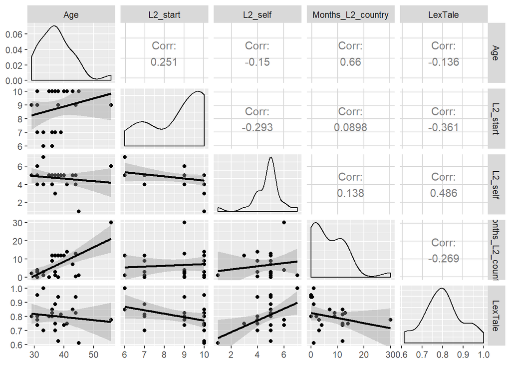

```r
ggpairs(backgr[, c(2, 4:7)], lower = list(continuous = "smooth"))
```

Let’s look at the LexTale scores:

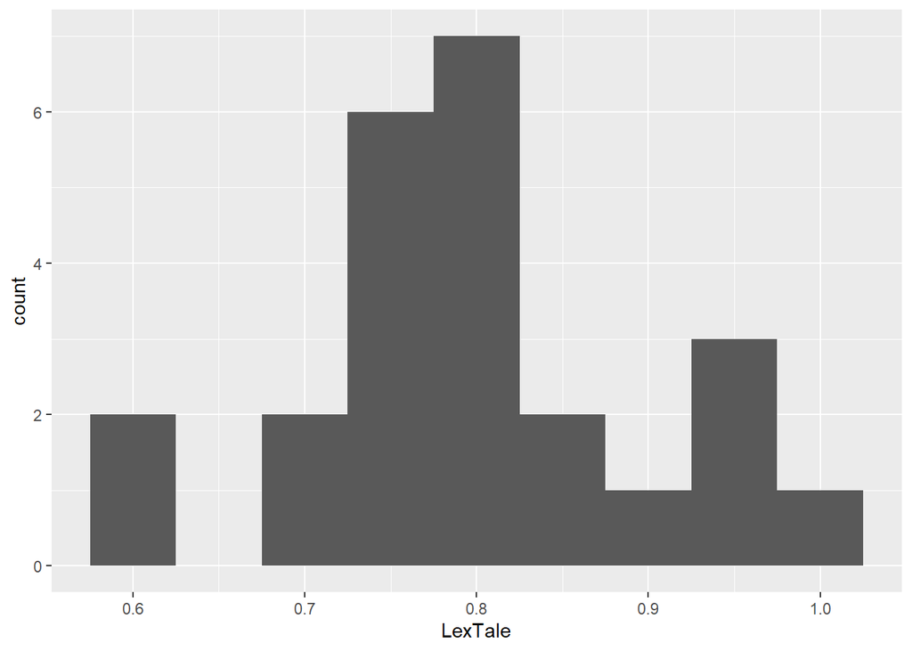

```r
ggplot(backgr, aes(x = LexTale)) + geom_histogram(binwidth = .05)
```

### 4.4.2 Correlation of proficiency and form/category task in L2

```r
# Subset form/category task data in L2 only:
d_fc_l2 <- d_fc_subj %>% select(-Outlier) %>% filter(Language == "L2")
# Add their proficiency scores:
d_fc_l2 <- left_join(d_fc_l2, backgr %>% select(Subject, LexTale))
```

Plot:

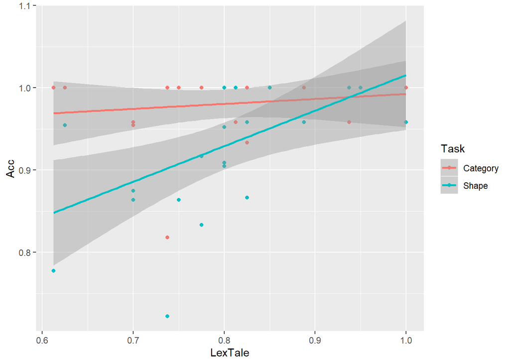

```r
ggplot(d_fc_l2, aes(x = LexTale, y = Acc, colour = Task)) +
  geom_point() +
  geom_smooth(method = "lm")
```

So this seems to go well with our story:

- L2 proficiency did not really predict their performance on the category task (which was close to ceiling anyway)
- However, it did correlate with their performance on the *shape* task, as we expected

Here are the corresponding Pearson correlation tests:

```r
by(d_fc_l2, d_fc_l2$Task, function(df) with(df, cor.test(Acc, LexTale)))
```

```
## d_fc_l2$Task: Category
##
##  Pearson's product-moment correlation
##
## data:  Acc and LexTale
## t = 0.67728, df = 22, p-value = 0.5053
## alternative hypothesis: true correlation is not equal to 0
## 95 percent confidence interval:
##  -0.2764189  0.5165318
## sample estimates:
##       cor
## 0.1429136
##
## --------------------------------------------------------
## d_fc_l2$Task: Shape
##
##  Pearson's product-moment correlation
##
## data:  Acc and LexTale
## t = 2.9567, df = 22, p-value = 0.00729
## alternative hypothesis: true correlation is not equal to 0
## 95 percent confidence interval:
##  0.1654526 0.7708366
## sample estimates:
##       cor
## 0.5332581
```

# 5 Inference task

## 5.1 Accuracy

We first look at accuracy:

### 5.1.1 By subject

Summarize each participant’s data as a single number, namely their mean accuracy (`Acc`) in each task and language:

```r
d_infe_subj <- d_infe %>%
  group_by(Subject, Language, Type) %>%
  summarise(Acc = mean(Score))
head(d_infe_subj)
```

```
## # A tibble: 6 x 4
## # Groups:   Subject, Language [2]
##   Subject Language Type      Acc
##     <int> <chr>    <chr>   <dbl>
## 1       1 L1       Control 0.625
## 2       1 L1       Spatial 0.875
## 3       1 L1       Visual  1
## 4       1 L2       Control 1
## 5       1 L2       Spatial 0.625
## 6       1 L2       Visual  1
```

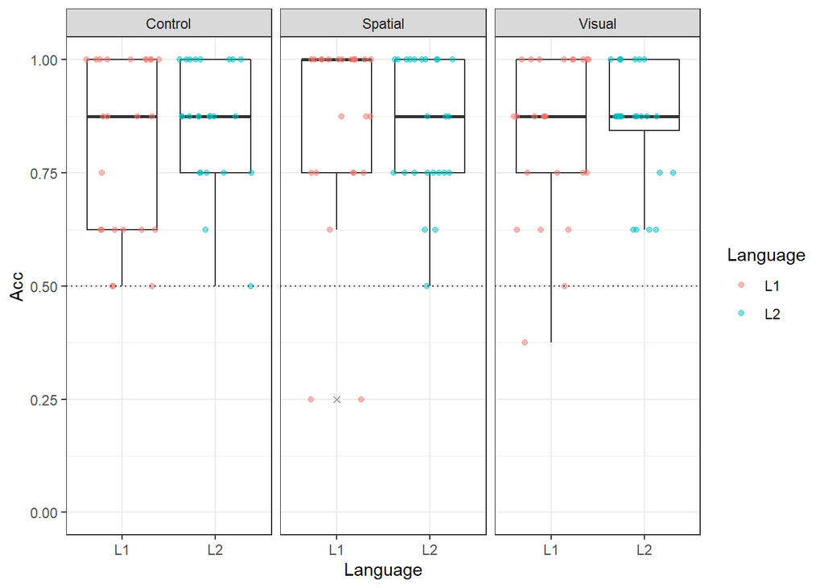

```r
ggplot(d_infe_subj, aes(x = Language, y = Acc)) +
  geom_boxplot(outlier.shape = 4) +
  geom_jitter(height = 0, alpha = .5, aes(colour = Language)) +
  facet_grid(. ~ Type) +
  ylim(0, 1) +
  geom_hline(yintercept = .5, linetype = "dotted") +
  theme_bw()
```

Let us see if either the valid or invalid inferences were more difficult:

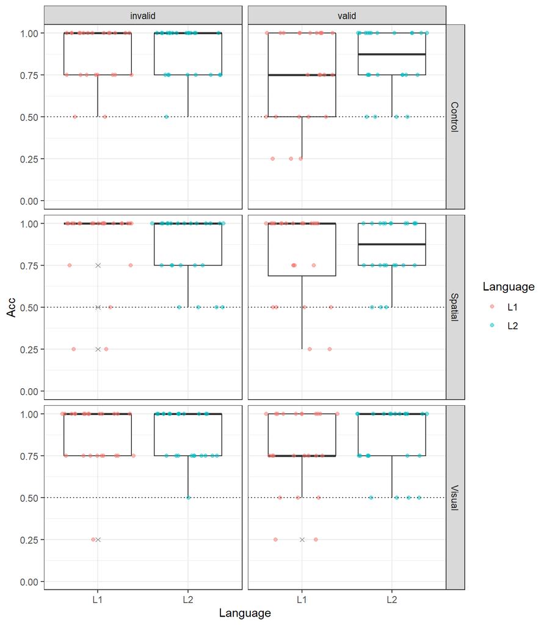

```r
d_infe %>%
  mutate(Val = ifelse(Valid == 1, "valid", "invalid")) %>%
  group_by(Subject, Language, Type, Val) %>%
  summarise(Acc = mean(Score)) %>%
  ggplot(aes(x = Language, y = Acc)) +
  geom_boxplot(outlier.shape = 4) +
  geom_jitter(height = 0, alpha = .5, aes(colour = Language)) +
  facet_grid(Type ~ Val) +
  ylim(0, 1) +
  geom_hline(yintercept = .5, linetype = "dotted") +
  theme_bw()
```

There is actually not much evidence that invalid inferences are harder than valid ones, or the other way around.

### 5.1.2 By-item (i.e., by inference pattern)

Let’s do an analogous visualization but no grouping by inference pattern (`InferPattern`) rather than subject:

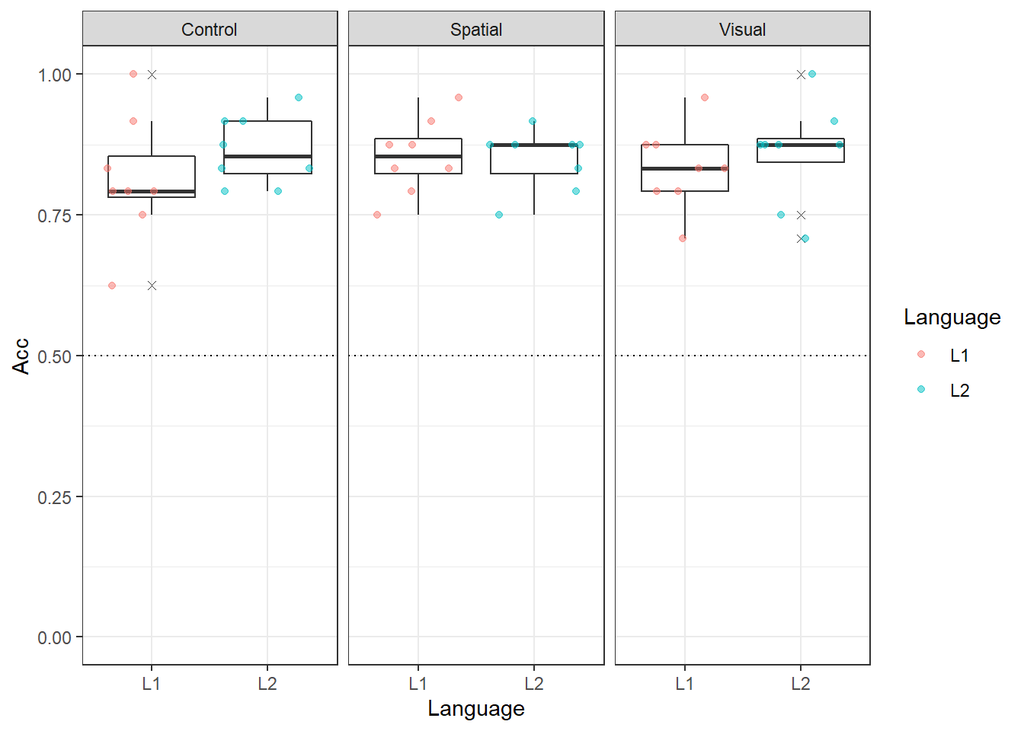

```r
d_infe_ite <- d_infe %>%
  mutate(Val = ifelse(Valid == 1, "valid", "invalid")) %>%
  group_by(InferPattern, Language, Type, Val) %>%
  summarise(Acc = mean(Score))

ggplot(d_infe_ite, aes(x = Language, y = Acc)) +
  geom_boxplot(outlier.shape = 4) +
  geom_jitter(height = 0, alpha = .5, aes(colour = Language)) +
  facet_grid(. ~ Type) +
  ylim(0, 1) +
  geom_hline(yintercept = .5, linetype = "dotted") +
  theme_bw()
```

Interestingly, there seems to be less variation in the items than in subjects. So all inference patterns were roughly equally hard.

We can also colour the dots with regard to validity of the items, to see if we see some evidence now of valid vs invalid items having a different degree of difficulty:

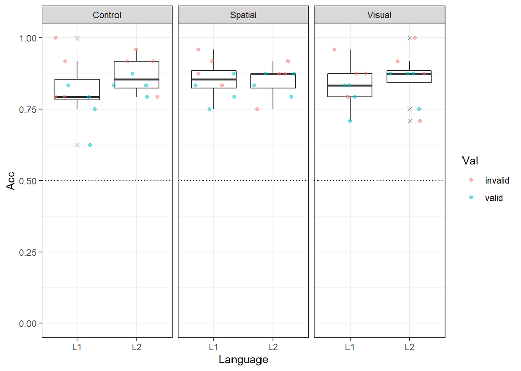

```r
ggplot(d_infe_ite, aes(x = Language, y = Acc)) +
  geom_boxplot(outlier.shape = 4) +
  geom_jitter(height = 0, alpha = .5, aes(colour = Val)) +
  facet_grid(. ~ Type) +
  ylim(0, 1) +
  geom_hline(yintercept = .5, linetype = "dotted") +
  theme_bw()
```

We can make the comparison even more explicit, as we did above between subjects:

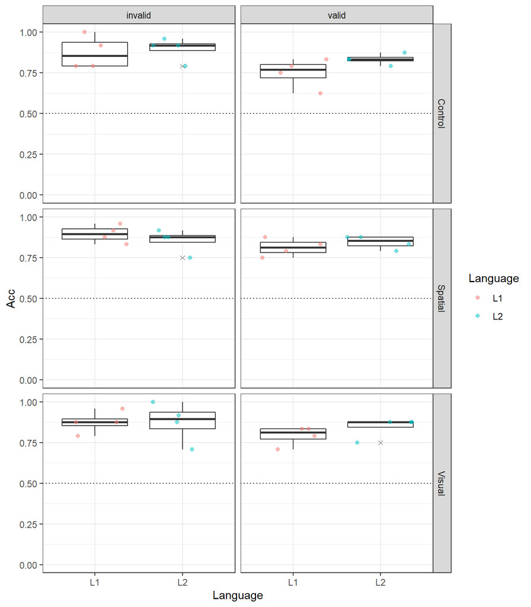

```r
ggplot(d_infe_ite, aes(x = Language, y = Acc)) +
  geom_boxplot(outlier.shape = 4) +
  geom_jitter(height = 0, alpha = .5, aes(colour = Language)) +
  facet_grid(Type ~ Val) +
  ylim(0, 1) +
  geom_hline(yintercept = .5, linetype = "dotted") +
  theme_bw()
```

Perhaps there is an indication that invalid inferences yielded slightly higher accuracies. This in turn could be due to participants having a slight bias towards rejecting the validity of inferences…

**It would probably be a good idea to compute d’ (*d-prime*) scores!**

## 5.2 Response times

### 5.2.1 General overview

First we need to get an idea of how response times (RTs) were distributed: How much dispersion was there within and between participants? Were the distributions very skewed?

```r
# Compute by speaker averages for later plotting and add that to data frame
mean_RT <- d_infe %>% group_by(Subject) %>%
  summarise(Mean_RT = mean(RT),
            Median_RT = median(RT))
d_infe <- left_join(d_infe, mean_RT)
# Order Subject levels according to Median_RT
d_infe$Subject <- factor(d_infe$Subject, levels = mean_RT$Subject[order(mean_RT$Median_RT)])
```

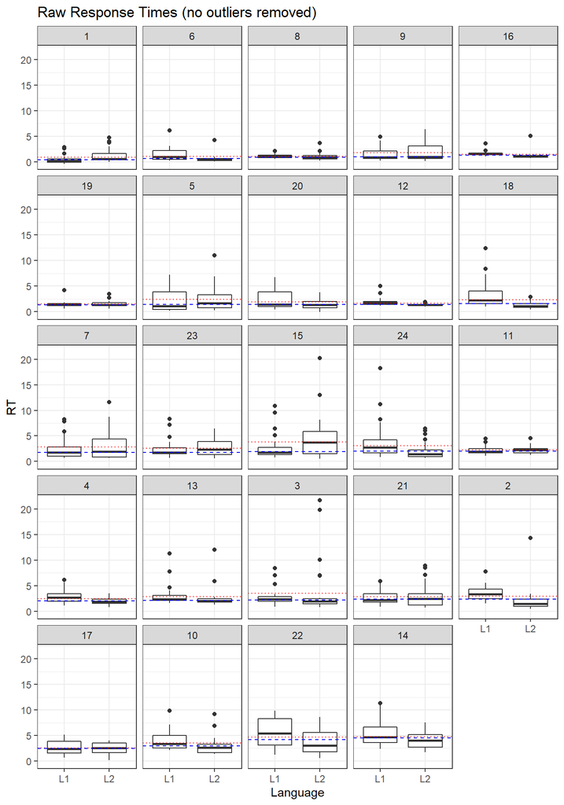

```r
ggplot(d_infe, aes(x = Language, y = RT)) +
  geom_boxplot() +
  facet_wrap(~ Subject) +
  geom_hline(aes(yintercept = Mean_RT), linetype = "dotted", colour = "red") +
  geom_hline(aes(yintercept = Median_RT), linetype = "dashed", colour = "blue") +
  ggtitle("Raw Response Times (no outliers removed)") +
  theme_bw()
```

This plot is not very useful because some extreme observations compress most of the data to the bottom of the plots.

Here is a data summary:

```r
summary(d_infe$RT)
```

```
##    Min. 1st Qu.  Median    Mean 3rd Qu.    Max.
## -0.4097  1.1421  1.8107  2.5256  3.1631 21.6835
```

While 75% of the data are RT < 3.163059, extreme observations go above 20 seconds!

Let us just plot the data again but now cutting out observations above 10:

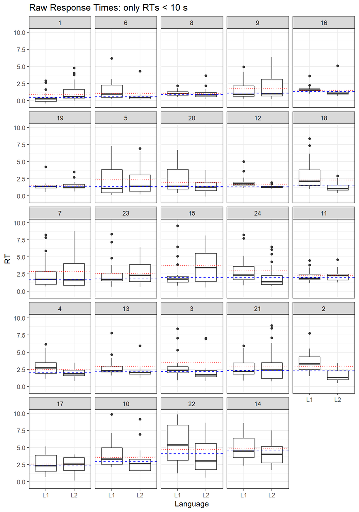

```r
ggplot(d_infe, aes(x = Language, y = RT)) +
  geom_boxplot() +
  facet_wrap(~ Subject) +
  geom_hline(aes(yintercept = Mean_RT), linetype = "dotted", colour = "red") +
  geom_hline(aes(yintercept = Median_RT), linetype = "dashed", colour = "blue") +
  ylim(-0.5, 10) +
  ggtitle("Raw Response Times: only RTs < 10 s") +
  theme_bw()
```

Now we get a much better sense of the data. Some notes about the plot here above:

- The data for each subject is plotted in a separate panel, with L1 data plotted on the left and L2 data on the right
- Subjects are ordered from fastest to slowest based on their *median* response time
- Each subject’s median is plotted as a blue dashed line; each subject’s mean as a red dotted line. (These lines are close for subjects with RTs roughly normally distributed)
- Note that for the slowest participants the plots are slightly misleading because the whiskers are cut off (e.g., participant 14, compare the plot directly here above with the first that was presented)

### 5.2.2 Correct vs incorrect trials

In the previous section, we looked at all the trials, independent of whether participants’ responses were correct or not. However, Knauff and May (2006) removed incorrect trials from the RT analyses, and so did Petrus. This is standard practice and it actually makes sense because one may wonder if subjects were even paying attention on incorrect trials.

First, let’s see RTs as a function of response accuracy:

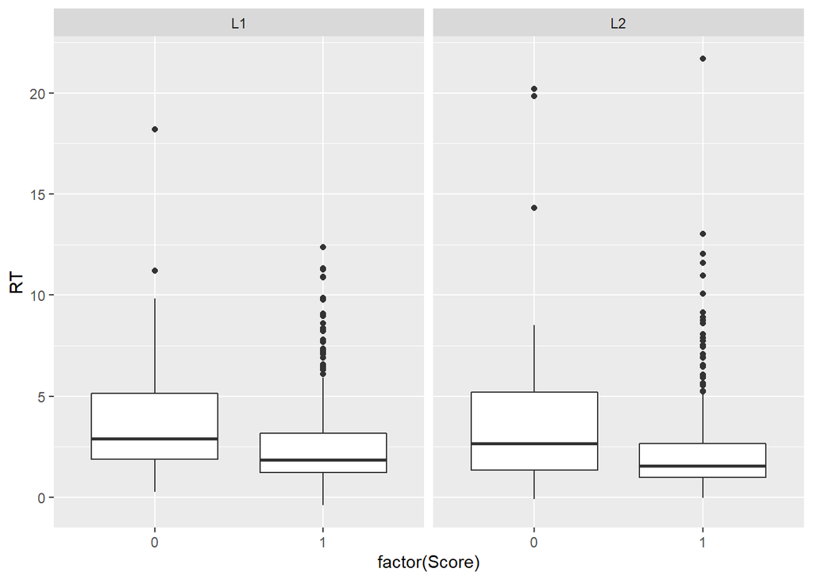

```r
ggplot(d_infe, aes(x = factor(Score), y = RT)) +
  geom_boxplot() +
  facet_grid(. ~ Language)
```

Indeed, in both L1 and L2 there is a tendency for incorrect trials to be associated to longer RTs:

```r
d_infe %>% group_by(Language, Score) %>%
  summarise(Mean_RT = mean(RT), SD_RT = sd(RT)) %>%
  kable
```

| Language | Score | Mean_RT | SD_RT |
| --- | --- | --- | --- |
| L1 | 0 | 3.811636 | 2.773496 |
| L1 | 1 | 2.460196 | 2.037651 |
| L2 | 0 | 3.665301 | 3.607126 |
| L2 | 1 | 2.150091 | 2.048157 |

Yes, the mean effect is indeed quite substantial: incorrect responses yield roughly 1.5 seconds longer RTs.

### 5.2.3 Data loss when removing incorrect trials

How many observations will be removed?

```r
table(d_infe$Score)
```

```
##
##   0   1
## 178 974
```

This amounts to 15.5% of the data.

Of interest is to see how much that will affect particular participants and particular items:

#### 5.2.3.1 Participants:

```r
d_infe %>%
  mutate(Error = ifelse(Score == 0, 1, 0)) %>%
  group_by(Subject) %>%
  summarise(nbErrors = sum(Error), nbObs = n()) %>%
  mutate(dataLossPerc = round(100 * nbErrors / nbObs)) %>%
  arrange(-nbErrors) %>%
  select(Subject, nbErrors, dataLossPerc) %>%
  print(n = 24)
```

```
## # A tibble: 24 x 3
##    Subject nbErrors dataLossPerc
##    <fct>      <dbl>        <dbl>
##  1 23            22           46
##  2 22            15           31
##  3 24            14           29
##  4 14            14           29
##  5 17            12           25
##  6 2             11           23
##  7 19            10           21
##  8 6              8           17
##  9 20             8           17
## 10 12             8           17
## 11 1              7           15
## 12 7              7           15
## 13 10             7           15
## 14 9              6           12
## 15 5              6           12
## 16 15             6           12
## 17 21             5           10
## 18 3              4            8
## 19 18             3            6
## 20 4              2            4
## 21 8              1            2
## 22 16             1            2
## 23 11             1            2
## 24 13             0            0
```

For some participants (e.g., 23 or 22) data loss is quite substantial.

We can actually break it down by Language to see if some cases become even more extreme then:

```r
d_infe %>%
  mutate(Error = ifelse(Score == 0, 1, 0)) %>%
  group_by(Subject, Language) %>%
  summarise(nbErrors = sum(Error), nbObs = n()) %>%
  mutate(dataLossPerc = round(100 * nbErrors / nbObs)) %>%
  arrange(-nbErrors) %>%
  select(Subject, Language, nbErrors, dataLossPerc)
```

```
## # A tibble: 48 x 4
## # Groups:   Subject [24]
##    Subject Language nbErrors dataLossPerc
##    <fct>   <chr>       <dbl>        <dbl>
##  1 23      L1             12           50
##  2 14      L1             11           46
##  3 23      L2             10           42
##  4 22      L1             10           42
##  5 19      L2              9           38
##  6 24      L1              9           38
##  7 12      L1              7           29
##  8 9       L2              6           25
##  9 20      L1              6           25
## 10 2       L2              6           25
## # ... with 38 more rows
```

The picture does not change radically.

```r
d_infe_corr <- d_infe %>% filter(Score == 1)
```

#### 5.2.3.2 Items (inference patterns):

```r
d_infe %>%
  mutate(Error = ifelse(Score == 0, 1, 0)) %>%
  group_by(InferPattern, Type) %>%
  summarise(nbErrors = sum(Error), nbObs = n()) %>%
  mutate(dataLossPerc = round(100 * nbErrors / nbObs)) %>%
  arrange(-nbErrors) %>%
  select(InferPattern, nbErrors, dataLossPerc)
```

```
## # A tibble: 24 x 3
## # Groups:   InferPattern [8]
##    InferPattern                 nbErrors dataLossPerc
##    <chr>                           <dbl>        <dbl>
##  1 1) B-r-A; 2) B-R-C; 3) C-r-A       13           27
##  2 1) A-r-B; 2) C-R-B; 3) A-r-C       12           25
##  3 1) A-r-C; 2) A-R-B; 3) C-r-B       12           25
##  4 1) A-r-B; 2) A-R-C; 3) C-r-B       10           21
##  5 1) A-r-B; 2) A-R-C; 3) C-r-B       10           21
##  6 1) A-r-B; 2) C-R-B; 3) A-r-C       10           21
##  7 1) B-r-A; 2) C-R-A; 3) B-r-C       10           21
##  8 1) A-r-B; 2) C-R-B; 3) A-r-C        8           17
##  9 1) B-r-A; 2) B-R-C; 3) C-r-A        8           17
## 10 1) B-r-C; 2) B-R-A; 3) C-r-A        8           17
## # ... with 14 more rows
```

The differences in accuracy between items / inference patterns are not as pronounced as between subjects.

### 5.2.4 Exclude incorrect trials

In any case, it makes sense to exclude incorrect trials from further analysis:

```r
d_infe_corr <- d_infe %>% filter(Score == 1)
```

### 5.2.5 Log-transorm the data to avoid the strong right-skew?

If we look at the raw RTs data as a whole, we see that it is strongly right-skewed:

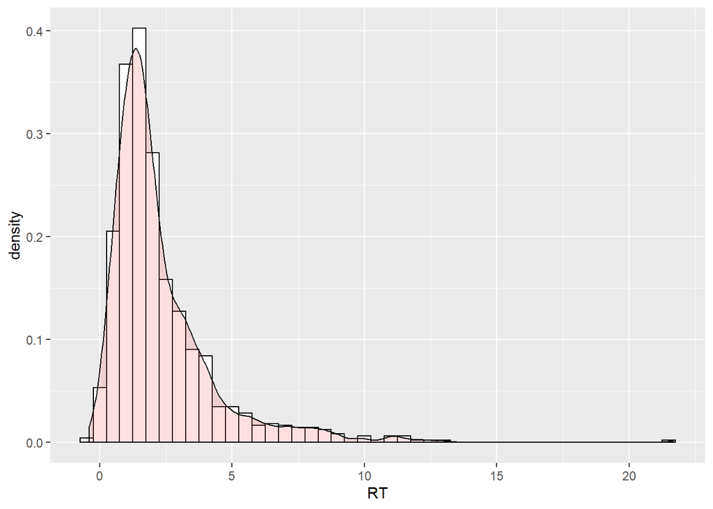

```r
# Following
# http://www.cookbook-r.com/Graphs/Plotting_distributions_(ggplot2)/
ggplot(d_infe_corr, aes(x = RT)) +
  geom_histogram(aes(y=..density..),  # Histogram with density instead of count on y-axis
                 binwidth=.5, colour="black", fill="white") +
  geom_density(alpha=.2, fill="#FF6666")  # Overlay with transparent density plot
```

In situations like this, taking the log of the DV can be helpful:

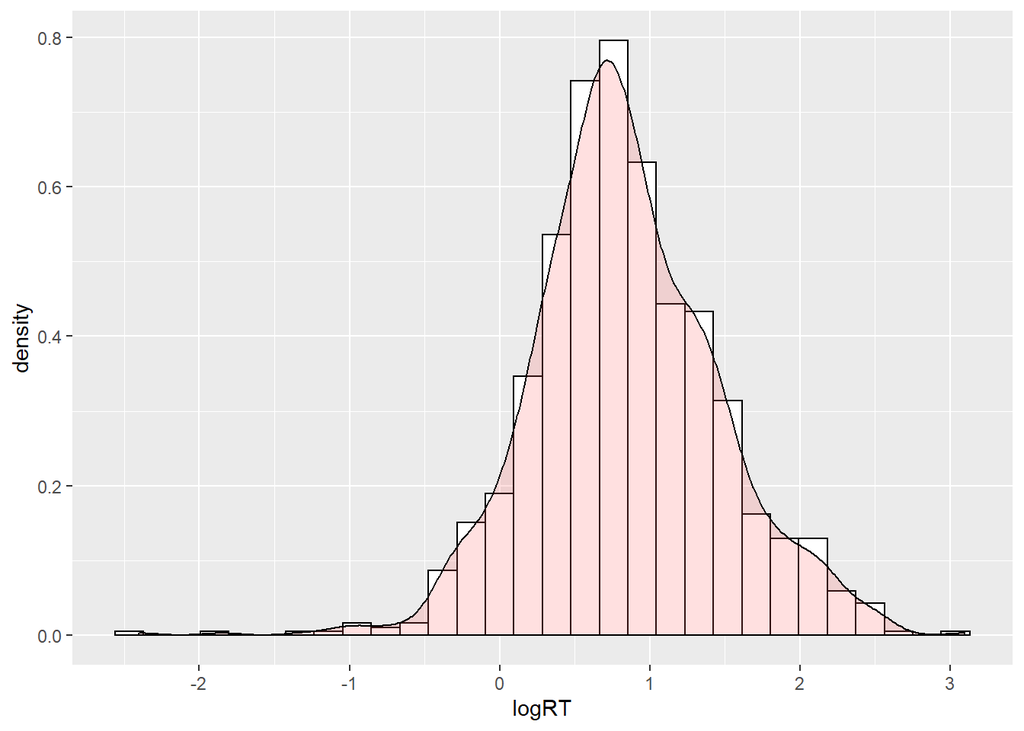

```r
# Because log of negative number is not defined, we somewhat arbitrarily add
# 0.5 to all RTs (just a shift in scale) to make them all positive:
d_infe_corr$logRT <- log(d_infe_corr$RT + 0.5)
ggplot(d_infe_corr, aes(x = logRT)) +
  geom_histogram(aes(y=..density..),  # Histogram with density instead of count on y-axis
                 colour="black", fill="white") +
  geom_density(alpha=.2, fill="#FF6666")  # Overlay with transparent density plot
```

The distribution of `logRT`s is much less skewed, although we might now observe a slight left-skew instead. Note that this transformation is a monotonically increasing function, so the order of the observations is preserved.

Let us look at the same plot of by-subject observations as above, but now using the log-transformed RT data.

```r
# Compute by speaker averages and medians for logRT
mean_logRT <- d_infe_corr %>% group_by(Subject) %>%
  summarise(Mean_logRT = mean(logRT),
            Median_logRT = median(logRT))
d_infe_corr <- left_join(d_infe_corr, mean_logRT)
# Order Subject levels according to Median_logRT now
d_infe_corr$Subject <- factor(
  d_infe_corr$Subject,
  levels = mean_logRT$Subject[order(mean_logRT$Median_logRT)]
  )
```

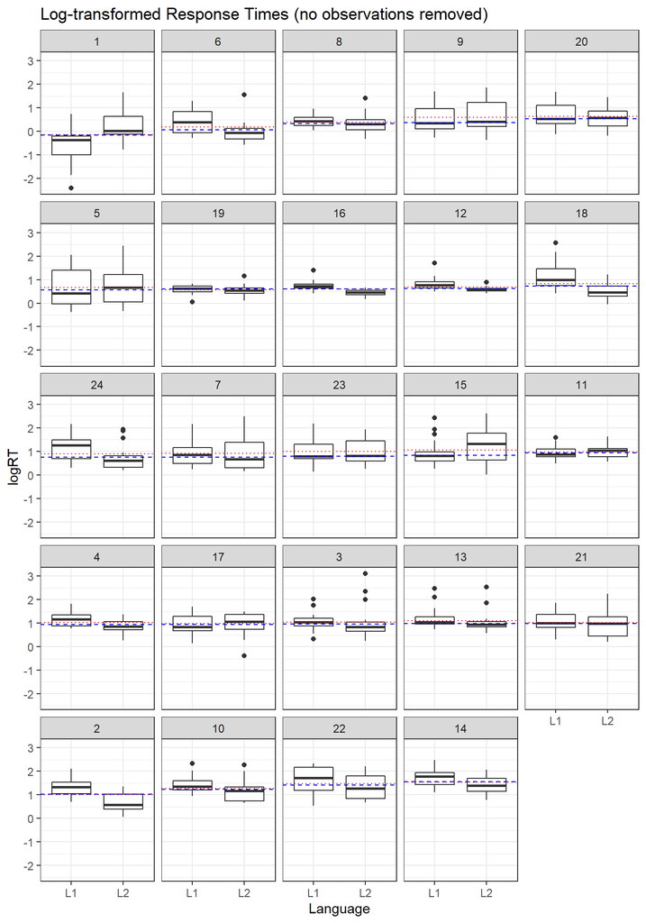

```r
ggplot(d_infe_corr, aes(x = Language, y = logRT)) +
  geom_boxplot() +
  facet_wrap(~ Subject) +
  geom_hline(aes(yintercept = Mean_logRT), linetype = "dotted", colour = "red") +
  geom_hline(aes(yintercept = Median_logRT), linetype = "dashed", colour = "blue") +
  ggtitle("Log-transformed Response Times (no observations removed)") +
theme_bw()
```

Under the log transformation, the problem of removing outliers, which always involves arbitrary cutoffs, is largely avoided.

**We will therefore proceed with log-transformed data for now. Later, however, we will re-run the analyses using the approach adopted by Knauff & May (2006)**, which is also what Petrus did in his follow-up analysis.

A note on the interpretation of log-RTs in regression analysis:

There is a different assumption underlying the choice of whether to analyze the dependent variable reaction time as raw scores or on a logarithmic scale. The assumption has to do with how one believes the manipulations to be related to the DV. Taking raw RTs assumes that the effect of the predictor on the DV will be linear, i.e. a regression coefficient of 2 would indicate that RTs increase by adding 2 for any unit you move on the predictor. However, if you model the DV as logRT, we assume that the effect is multiplicative. This means that a regression coefficient of 2 indicates that RTs are *multiplied* by 2.

This is important to keep in mind for the analyses.

### 5.2.6 By subject

```r
# Summarize RTs by subject
rt_subj <- d_infe_corr %>%
  group_by(Subject, Language, Type) %>%
  summarise(logRT = mean(logRT))
head(rt_subj, 7)
```

```
## # A tibble: 7 x 4
## # Groups:   Subject, Language [3]
##   Subject Language Type      logRT
##   <fct>   <chr>    <chr>     <dbl>
## 1 1       L1       Control -0.467
## 2 1       L1       Spatial -0.475
## 3 1       L1       Visual  -0.749
## 4 1       L2       Control  0.0778
## 5 1       L2       Spatial  0.245
## 6 1       L2       Visual   0.470
## 7 6       L1       Control  0.200
```

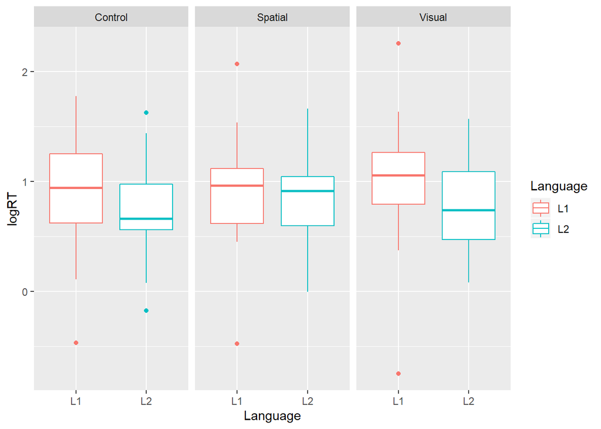

```r
ggplot(rt_subj, aes(x = Language, y = logRT, colour = Language)) +
  geom_boxplot() +
  facet_grid(. ~ Type)
```

Indeed, the data at least numerically show the expected tendency: The visual type of inferences were more demanding in the L1 than in the L2.

Perhaps a more insightful plot is one that is created by plotting per-cell means and 95% confidence intervals (assuming normality, i.e. +/- 2 SE).

```r
sem_fun <- function(x) sd(x) / sqrt(length(x))
rt_subj_summ <- rt_subj %>%
  group_by(Language, Type) %>%
  summarise(M = mean(logRT), SE = sem_fun(logRT))
rt_subj_summ
```

```
## # A tibble: 6 x 4
## # Groups:   Language [2]
##   Language Type        M     SE
##   <chr>    <chr>   <dbl>  <dbl>
## 1 L1       Control 0.873 0.102
## 2 L1       Spatial 0.888 0.0959
## 3 L1       Visual  1.01  0.116
## 4 L2       Control 0.739 0.0872
## 5 L2       Spatial 0.841 0.0760
## 6 L2       Visual  0.788 0.0748
```

First, just means and 95% confidence intervals:

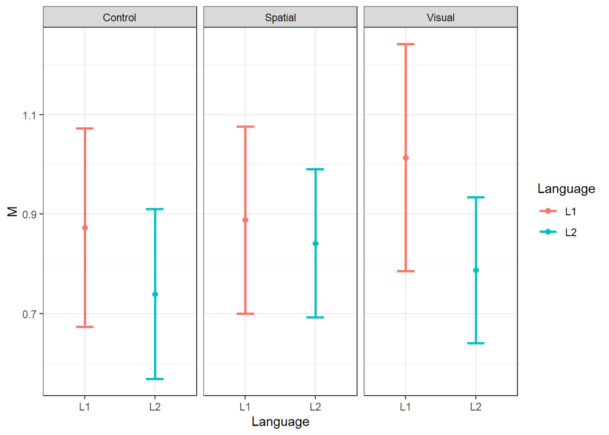

```r
ggplot(rt_subj_summ, aes(x = Language, y = M, colour = Language)) +
  geom_point(size = 2) +
  geom_errorbar(aes(ymin = M - 1.96 * SE, ymax = M + 1.96 * SE), width = .25,
                size = 1) +
  facet_grid(. ~ Type) +
  theme_bw()
```

But we can also overlay the individual subject means to get a better idea of the dispersion in the data.

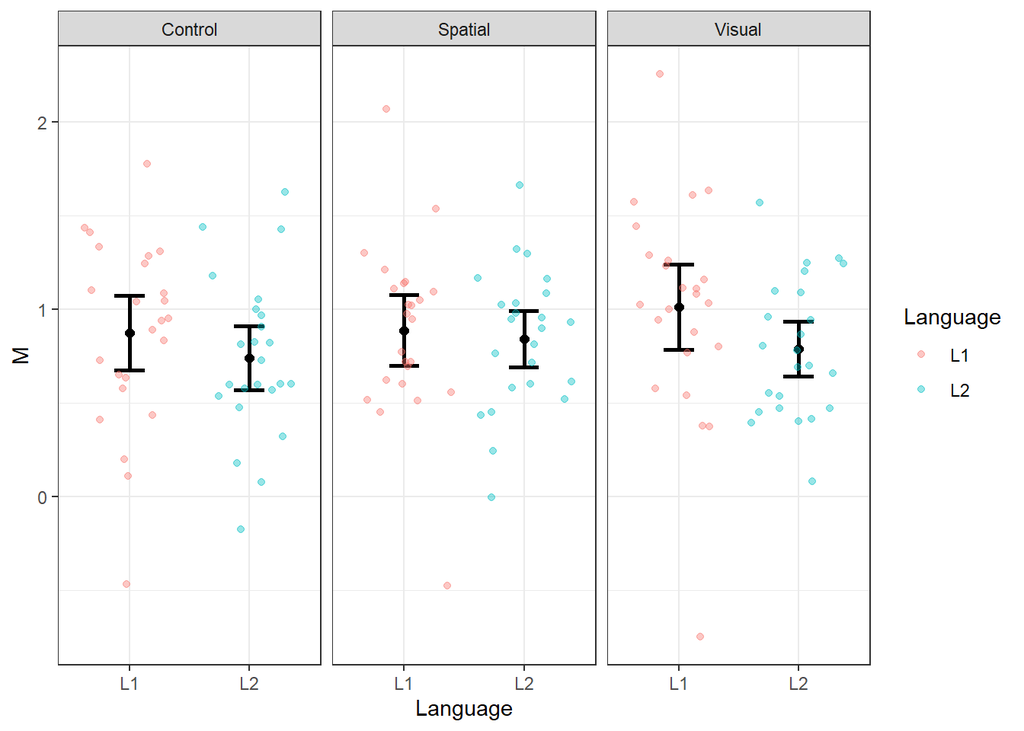

```r
ggplot(rt_subj_summ, aes(x = Language, y = M)) +
  geom_point(size = 2) +
  geom_errorbar(aes(ymin = M - 1.96 * SE, ymax = M + 1.96 * SE), width = .25,
                size = 1) +
  geom_jitter(data = rt_subj, aes(y = logRT, colour = Language), height = 0,
              alpha = .4) +
  facet_grid(. ~ Type) +
  theme_bw()
```

We can add a little bit more of information to the graph by connecting observations from the same speaker in the different languages. This basically shows individual by-subject slopes (as will later be captured by the random effects in linear mixed model, LMM).

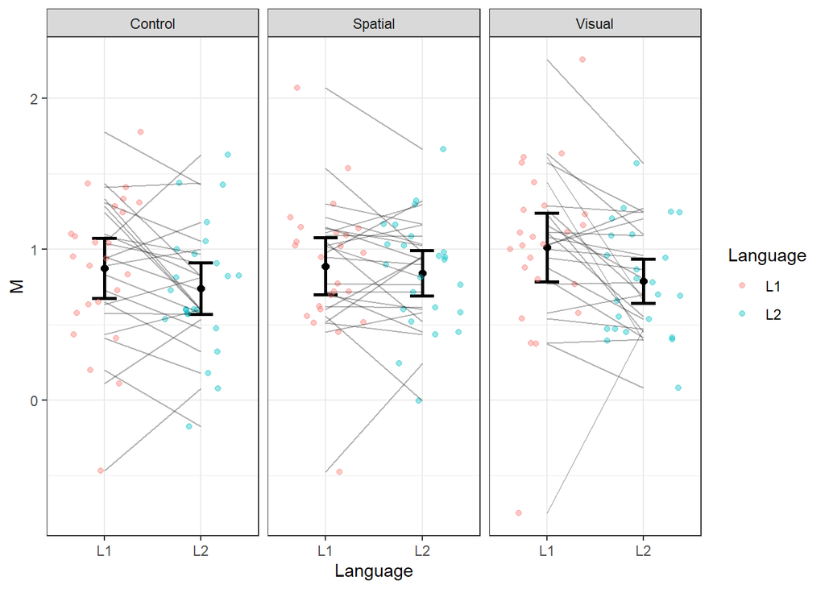

```r
ggplot(rt_subj_summ, aes(x = Language, y = M)) +
  geom_point(size = 2) +
  geom_errorbar(aes(ymin = M - 1.96 * SE, ymax = M + 1.96 * SE), width = .25,
                size = 1) +
  geom_jitter(data = rt_subj, aes(y = logRT, colour = Language), height = 0,
              alpha = .4) +
  geom_line(data = rt_subj, aes(y = logRT, group = Subject), alpha = .3) +
  facet_grid(. ~ Type) +
  theme_bw()
```

For AMLaP abstract:

```r
# NB: We remove control condition, for clarity.
rt_subj_amlap <- rt_subj %>% filter(Type != "Control")
rt_subj_amlap
```

```
## # A tibble: 96 x 4
## # Groups:   Subject, Language [48]
##    Subject Language Type       logRT
##    <fct>   <chr>    <chr>      <dbl>
##  1 1       L1       Spatial -0.475
##  2 1       L1       Visual  -0.749
##  3 1       L2       Spatial  0.245
##  4 1       L2       Visual   0.470
##  5 6       L1       Spatial  0.556
##  6 6       L1       Visual   0.373
##  7 6       L2       Spatial -0.00250
##  8 6       L2       Visual   0.0806
##  9 8       L1       Spatial  0.514
## 10 8       L1       Visual   0.379
## # ... with 86 more rows
```

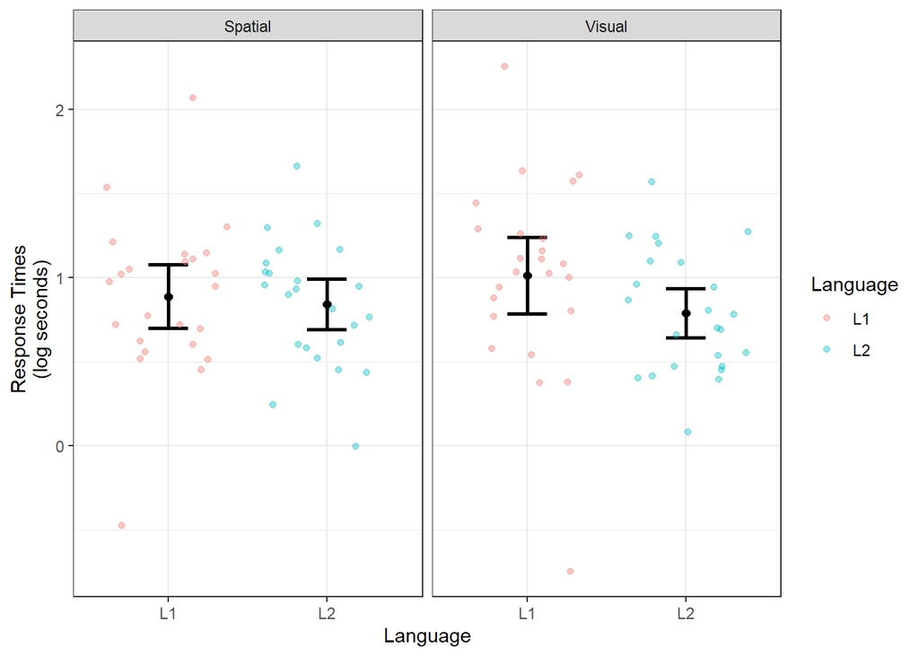

```r
rt_subj_summ <- rt_subj %>%
  group_by(Language, Type) %>%
  summarise(M = mean(logRT), SE = sem_fun(logRT))

rt_subj_summ %>%
  filter(Type != "Control") %>%
ggplot(aes(x = Language, y = M)) +
  geom_point(size = 2) +
  geom_errorbar(aes(ymin = M - 1.96 * SE, ymax = M + 1.96 * SE), width = .25,
                size = 1) +
  geom_jitter(data = rt_subj %>% filter(Type != "Control"), aes(y = logRT, colour = Language), height = 0,
              alpha = .4) +
  facet_grid(. ~ Type) +
  ylab("Response Times\n(log seconds)") +
  theme_bw()
```

Save to disk (perhaps uncomment next line?)

```r
ggsave("fig_exp2_amlap.png", height = 2.5, width = 5)
ggsave("fig_exp2_amlap.pdf", height = 2.5, width = 5)
```

### 5.2.7 LMM analysis

Appropriate coding for factors:

```r
# Sum coding for Language
d_infe_corr$Language <- factor(d_infe_corr$Language)
contrasts(d_infe_corr$Language) <- - contr.sum(2)
colnames(contrasts(d_infe_corr$Language)) <- "L2_vs_L1"
contrasts(d_infe_corr$Language)
```

```
##    L2_vs_L1
## L1       -1
## L2        1
```

```r
# Type, with 2 possibilities
# 1) Helmert coding
d_infe_corr$Type <- factor(d_infe_corr$Type)
contrasts(d_infe_corr$Type) <- contr.helmert(3)
colnames(contrasts(d_infe_corr$Type)) <- c("Spat_vs_Cont", "Visual_vs_rest")
contrasts(d_infe_corr$Type)
```

```
##         Spat_vs_Cont Visual_vs_rest
## Control           -1             -1
## Spatial            1             -1
## Visual             0              2
```

```r
contrasts(d_infe_corr$Language)
```

```
##    L2_vs_L1
## L1       -1
## L2        1
```

```r
# # 2) Treatment/dummy coding
# d_infe_corr$Type <- factor(d_infe_corr$Type,
#                            levels = c( "Visual", "Control", "Visuospatial"))
# contrasts(d_infe_corr$Type) <- contr.treatment(3)
# colnames(contrasts(d_infe_corr$Type)) <- c("Contr-vs-Visu", "Spat-vs-Visu")
# contrasts(d_infe_corr$Type)
```

Run the models (or comment them as they take a long time)

```r
# # Model with critical interaction
# fm_RT <- lmer(logRT ~ Language * Type +
#                 (1 + Language * Type | Subject) +
#                 (1 + Language * Type | InferPattern),
#               data = d_infe_corr, REML = FALSE)
# summary(fm_RT)
# # Model WITHOUT critical interaction
# fm_RT_nointeract <- lmer(logRT ~ Language + Type +
#                            (1 + Language * Type | Subject) +
#                            (1 + Language * Type | InferPattern),
#                          data = d_infe_corr, REML = FALSE)
# summary(fm_RT_nointeract)
```

The interaction of Type and Language does not come out as significant in a LRT:

```r
# anova(fm_RT, fm_RT_nointeract)
```

```
> anova(fm_RT, fm_RT_nointeract)
Data: d_infe_corr
Models:
fm_RT_nointeract: logRT ~ Language + Type + (1 + Language * Type | Subject) + (1 +
fm_RT_nointeract:     Language * Type | InferPattern)
fm_RT: logRT ~ Language * Type + (1 + Language * Type | Subject) + (1 +
fm_RT:     Language * Type | InferPattern)
                 Df    AIC    BIC  logLik deviance  Chisq Chi Df Pr(>Chisq)
fm_RT_nointeract 47 1521.7 1751.1 -713.82   1427.7
fm_RT            49 1523.1 1762.3 -712.54   1425.1 2.5616      2     0.2778
```

Here’s the model output for the model with the interaction:

```
> summary(fm_RT)
Linear mixed model fit by maximum likelihood  ['lmerMod']
Formula: logRT ~ Language * Type + (1 + Language * Type | Subject) + (1 +      Language * Type | InferPattern)
   Data: d_infe_corr

     AIC      BIC   logLik deviance df.resid
  1523.1   1762.3   -712.5   1425.1      925

Scaled residuals:
    Min      1Q  Median      3Q     Max
-3.5047 -0.6103 -0.1109  0.4601  4.3374

Random effects:
 Groups       Name                                Variance  Std.Dev. Corr
 Subject      (Intercept)                         0.1381110 0.37163
              LanguageL2_vs_L1                    0.0171943 0.13113  -0.48
              TypeSpat_vs_Cont                    0.0050948 0.07138   0.12 -0.21
              TypeVisual_vs_rest                  0.0016607 0.04075  -0.34 -0.35  0.23
              LanguageL2_vs_L1:TypeSpat_vs_Cont   0.0041746 0.06461   0.55 -0.37 -0.70 -0.39
              LanguageL2_vs_L1:TypeVisual_vs_rest 0.0009023 0.03004   0.41 -0.78  0.17  0.69  0.19
 InferPattern (Intercept)                         0.0007861 0.02804
              LanguageL2_vs_L1                    0.0026117 0.05111   0.50
              TypeSpat_vs_Cont                    0.0023259 0.04823  -0.66  0.13
              TypeVisual_vs_rest                  0.0002836 0.01684  -0.58  0.38  0.93
              LanguageL2_vs_L1:TypeSpat_vs_Cont   0.0011324 0.03365   0.47 -0.44 -0.94 -0.98
              LanguageL2_vs_L1:TypeVisual_vs_rest 0.0006039 0.02458   0.56 -0.07 -0.19 -0.45  0.27
 Residual                                         0.2157622 0.46450
Number of obs: 974, groups:  Subject, 24; InferPattern, 8

Fixed effects:
                                      Estimate Std. Error t value
(Intercept)                          0.8523357  0.0779858  10.929
LanguageL2_vs_L1                    -0.0650490  0.0356519  -1.825
TypeSpat_vs_Cont                    -0.0443093  0.0290458  -1.525
TypeVisual_vs_rest                   0.0002383  0.0147207   0.016
LanguageL2_vs_L1:TypeSpat_vs_Cont    0.0193417  0.0256148   0.755
LanguageL2_vs_L1:TypeVisual_vs_rest  0.0222186  0.0149935   1.482

Correlation of Fixed Effects:
            (Intr) LnL2__L1 TyS__C TypV__ LL2__L1:TS
LnggL2_v_L1 -0.323
TypSpt_vs_C  0.009 -0.044
TypVsl_vs_r -0.219 -0.066    0.288
LL2__L1:TS_  0.304 -0.246   -0.455 -0.296
LL2__L1:TV_  0.208 -0.262   -0.029  0.052  0.113
convergence code: 0
singular fit
```

### 5.2.8 A somewhat indirect subject analysis

One could also see if there is a correlation between how proficient speakers are in their L2 and how much of a “penalty” they pay for doing the inferences of the visual type.

The idea would here be that the lower your L2 proficiency is, the bigger the difference should be between how fast you are answering these inferences in your L1 and L2, and crucially, the relation should be as follows:

**Prediction**:

With lower L2 proficiency, the difference between RTs in the L1 and L2 for visual inferences should be greater (with an advantage in L2); with higher proficiency, the difference in RTs should be reduced or even zero.

Let us compute, for each subject, the difference in their L1/L2 RTs for visual items:

```r
RTs_proficiency <- d_infe_corr %>%
  filter(Type == "Visual") %>%
  group_by(Subject, Language) %>%
  summarise(M = mean(logRT)) %>%
  # From long to wide
  spread(Language, M) %>%
  # compute difference
  mutate(L1_minus_L2 = L1 - L2) %>%
  # Join with information about proficiency and accuracy in the shape task
  left_join(d_fc_l2 %>%
              ungroup() %>%
              mutate(Subject = as.character(Subject)) %>%
              filter(Task == "Shape") %>%
              select(Subject, Acc, LexTale))
head(RTs_proficiency)
```

```
## # A tibble: 6 x 6
## # Groups:   Subject [6]
##   Subject     L1     L2 L1_minus_L2   Acc LexTale
##   <chr>    <dbl>  <dbl>       <dbl> <dbl>   <dbl>
## 1 1       -0.749 0.470      -1.22   1       0.938
## 2 6        0.373 0.0806      0.293  0.909   0.8
## 3 8        0.379 0.405      -0.0255 0.958   0.825
## 4 9        0.769 0.781      -0.0115 0.955   0.625
## 5 20       0.577 0.697      -0.121  1       0.938
## 6 5        1.61  0.660       0.951  0.864   0.7
```

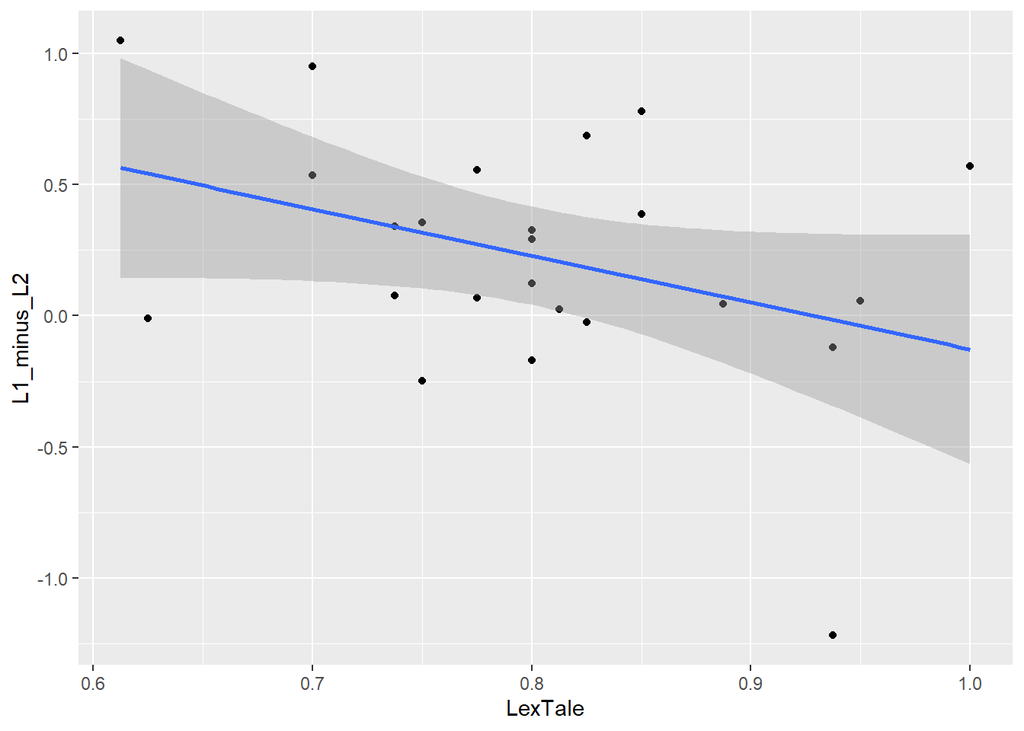

```r
ggplot(RTs_proficiency, aes(x = LexTale, y = L1_minus_L2)) +
  geom_point() +
  geom_smooth(method = "lm")
```

Pearson correlation test

```r
with(RTs_proficiency, cor.test(L1_minus_L2, LexTale))
```

```
##
##  Pearson's product-moment correlation
##
## data:  L1_minus_L2 and LexTale
## t = -1.8669, df = 22, p-value = 0.0753
## alternative hypothesis: true correlation is not equal to 0
## 95 percent confidence interval:
##  -0.67283276  0.03947676
## sample estimates:
##        cor
## -0.3698091
```

What about the accuracy?

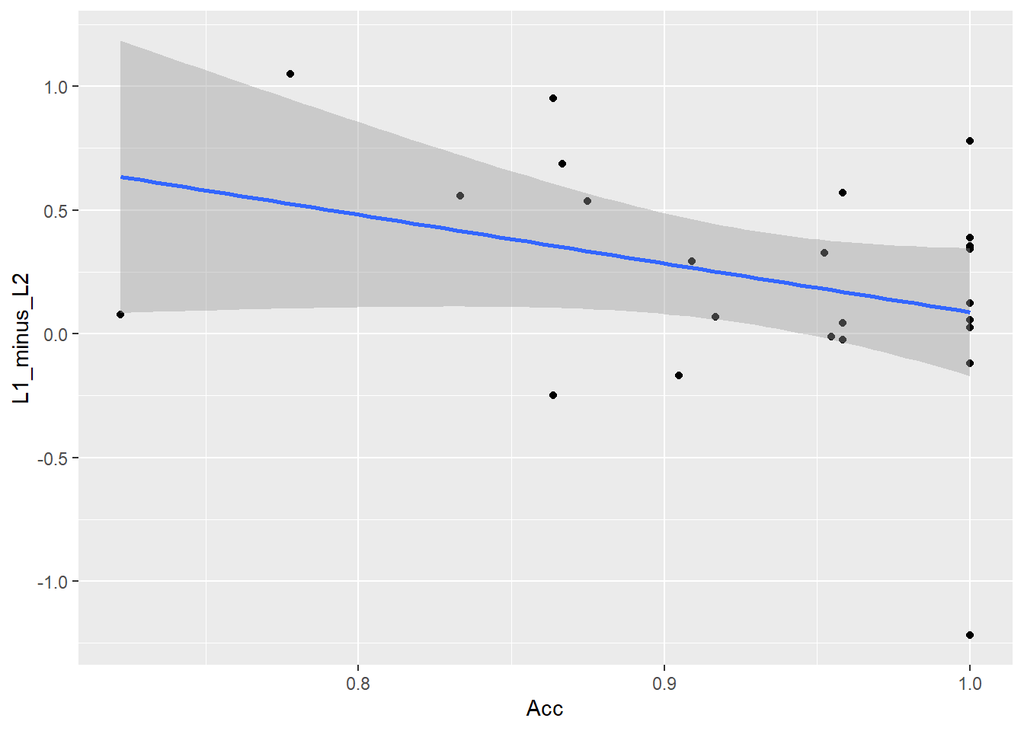

```r
ggplot(RTs_proficiency, aes(x = Acc, y = L1_minus_L2)) +
  geom_point() +
  geom_smooth(method = "lm")
```

Nahh…

```r
with(RTs_proficiency, cor.test(L1_minus_L2, Acc))
```

```
##
##  Pearson's product-moment correlation
##
## data:  L1_minus_L2 and Acc
## t = -1.6426, df = 22, p-value = 0.1147
## alternative hypothesis: true correlation is not equal to 0
## 95 percent confidence interval:
##  -0.64757905  0.08408147
## sample estimates:
##        cor
## -0.3305261
```

### 5.2.9 Analysis replacing outliers (as done by Knauff & May, 2006)

Knauff and May (2006) do not log-transform RTs. Instead they replace outliers with a certain cutoff value. Petrus in his thesis adopts the same approach in his follow-up analysis. This is described on p. 15-16 of his thesis (see `190107_isaksson_uppsats_slutv.pdf`).

Here is how the procedure is described by Petrus:

> Ett medelvärde räknades alltså ut för varje betingelse (här språk-typ) och de responstider som låg utanför avskärningspunkten för betingelsen -– “the cut-off of the condition” –- ersattes med detta värde. […] Värdet för avskärningspunkten refererar alltså här till (2(SD) + medel) för respektive betingelse.

I follow this approach and then carry out the same visualizations as above. I try to be explicit at each step so that it becomes easy to discover if I have done something differently to Petrus.

#### 5.2.9.1 Trimming the observations

```r
# Compute mean and SD of all RTs in each of the cells given by the six
# Language-Type combinations:
RT_cutoff <- d_infe_corr %>%
  group_by(Language, Type) %>%
  summarise(M = mean(RT), SD = sd(RT))
head(RT_cutoff)
```

```
## # A tibble: 6 x 4
## # Groups:   Language [2]
##   Language Type        M    SD
##   <fct>    <fct>   <dbl> <dbl>
## 1 L1       Control  2.43  2.16
## 2 L1       Spatial  2.21  1.70
## 3 L1       Visual   2.74  2.21
## 4 L2       Control  2.07  1.98
## 5 L2       Spatial  2.18  1.77
## 6 L2       Visual   2.20  2.36
```

```r
# Based on this we compute the upper and lower cutoff points:
RT_cutoff <- RT_cutoff %>%
  mutate(lower_cutoff = M - 2 * SD, upper_cutoff = M + 2 * SD)
head(RT_cutoff)
```

```
## # A tibble: 6 x 6
## # Groups:   Language [2]
##   Language Type        M    SD lower_cutoff upper_cutoff
##   <fct>    <fct>   <dbl> <dbl>        <dbl>        <dbl>
## 1 L1       Control  2.43  2.16        -1.88         6.74
## 2 L1       Spatial  2.21  1.70        -1.19         5.61
## 3 L1       Visual   2.74  2.21        -1.67         7.16
## 4 L2       Control  2.07  1.98        -1.88         6.02
## 5 L2       Spatial  2.18  1.77        -1.36         5.72
## 6 L2       Visual   2.20  2.36        -2.52         6.93
```

First we can see that no observations falls *below* any of the lower cutoff points, since the lowers RT is -0.41. So we need only to worry about observations higher than the upper cutoff points.

```r
# add the upper cutoff points to the data set:
d_infe_corr <- left_join(d_infe_corr,
                         RT_cutoff %>% select(Language, Type, upper_cutoff))
head(d_infe_corr)
```

```
##   Subject Language          Item Trial Score         RT
## 1       1       L1 audio/n20.wav     2     1 1.05983615
## 2       1       L1 audio/n22.wav     3     1 0.57540236
## 3       1       L1 audio/n17.wav     4     1 0.20931233
## 4       1       L1 audio/n24.wav     5     1 0.30904461
## 5       1       L1 audio/n10.wav     6     1 0.25691263
## 6       1       L1  audio/n9.wav     7     1 0.04089521
##                   InferPattern    Type Valid
## 1 1) B-r-A; 2) C-R-A; 3) B-r-C Control     1
## 2 1) B-r-A; 2) C-R-A; 3) B-r-C Spatial     1
## 3 1) B-r-C; 2) B-R-A; 3) C-r-A Control     0
## 4 1) B-r-C; 2) B-R-A; 3) C-r-A Spatial     0
## 5 1) A-r-B; 2) C-R-B; 3) A-r-C  Visual     1
## 6 1) C-r-A; 2) B-R-A; 3) B-r-C  Visual     0
##                                                  Description   Mean_RT
## 1     1) dog-worse-ape; 2) cat-better-ape; 3) dog-worse-cat? 0.8695608
## 2      1) dog-below-ape; 2) cat-above-ape; 3) dog-below-cat? 0.8695608
## 3     1) dog-worse-cat; 2) dog-better-ape; 3) cat-worse-ape? 0.8695608
## 4      1) dog-below-cat; 2) dog-above-ape; 3) cat-below-ape? 0.8695608
## 5 1) ape-thinner-dog; 2) cat-fatter-dog; 3) ape-thinner-cat? 0.8695608
## 6 1) cat-thinner-ape; 2) dog-fatter-ape; 3) dog-thinner-cat? 0.8695608
##   Median_RT       logRT Mean_logRT Median_logRT upper_cutoff
## 1 0.4172869  0.44458078 -0.1474841   -0.1535854     6.744130
## 2 0.4172869  0.07269488 -0.1474841   -0.1535854     5.606771
## 3 0.4172869 -0.34345932 -0.1474841   -0.1535854     6.744130
## 4 0.4172869 -0.21190122 -0.1474841   -0.1535854     5.606771
## 5 0.4172869 -0.27850745 -0.1474841   -0.1535854     7.159118
## 6 0.4172869 -0.61452971 -0.1474841   -0.1535854     7.159118
```

```r
# Add column containing RTs or cutoff points for outliers
d_infe_corr <- d_infe_corr %>%
  mutate(
    # Replaces outliers with cutoffs
    RT_trimmed = ifelse(RT <= upper_cutoff, RT, upper_cutoff),
    # Indicator variable to keep track of trimmed responses
    Trimmed = ifelse(RT <= upper_cutoff, 0, 1)
    )
head(d_infe_corr)
```

```
##   Subject Language          Item Trial Score         RT
## 1       1       L1 audio/n20.wav     2     1 1.05983615
## 2       1       L1 audio/n22.wav     3     1 0.57540236
## 3       1       L1 audio/n17.wav     4     1 0.20931233
## 4       1       L1 audio/n24.wav     5     1 0.30904461
## 5       1       L1 audio/n10.wav     6     1 0.25691263
## 6       1       L1  audio/n9.wav     7     1 0.04089521
##                   InferPattern    Type Valid
## 1 1) B-r-A; 2) C-R-A; 3) B-r-C Control     1
## 2 1) B-r-A; 2) C-R-A; 3) B-r-C Spatial     1
## 3 1) B-r-C; 2) B-R-A; 3) C-r-A Control     0
## 4 1) B-r-C; 2) B-R-A; 3) C-r-A Spatial     0
## 5 1) A-r-B; 2) C-R-B; 3) A-r-C  Visual     1
## 6 1) C-r-A; 2) B-R-A; 3) B-r-C  Visual     0
##                                                  Description   Mean_RT
```

[output cut: 20 more lines]

We should of course also ask ourselves how many observations we are trimming in this way:

```r
d_infe_corr %>%
  group_by(Language, Type) %>%
  summarise(NbTrimmed = sum(Trimmed))
```

```
## # A tibble: 6 x 3
## # Groups:   Language [2]
##   Language Type    NbTrimmed
##   <fct>    <fct>       <dbl>
## 1 L1       Control         9
## 2 L1       Spatial         8
## 3 L1       Visual          9
## 4 L2       Control         9
## 5 L2       Spatial         7
## 6 L2       Visual          7
```

Not that many: 49 trimmed observations in total.

Finally, let’s look at the distribution of data after trimming. Of course, the effect has been to cut off the long right tail of the distribution, while at the same time inflating the density for observations close to the cutoff (i.e., around 7 seconds):

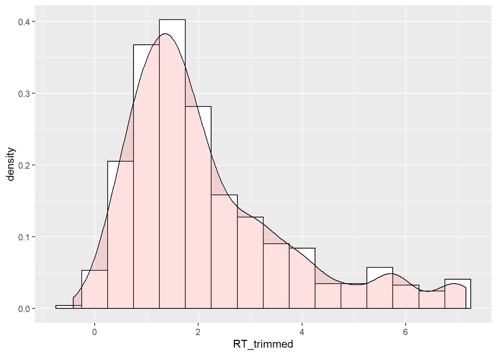

```r
ggplot(d_infe_corr, aes(x = RT_trimmed)) +
  geom_histogram(aes(y=..density..),  # Histogram with density instead of count on y-axis
                 binwidth=.5, colour="black", fill="white") +
  geom_density(alpha=.2, fill="#FF6666")  # Overlay with transparent density plot
```

#### 5.2.9.2 Repeat analyses above

##### 5.2.9.2.1 By subject

```r
# Summarize RTs by subject
rt_subj <- d_infe_corr %>%
  group_by(Subject, Language, Type) %>%
  summarise(RT_trimmed = mean(RT_trimmed))
head(rt_subj, 7)
```

```
## # A tibble: 7 x 4
## # Groups:   Subject, Language [3]
##   Subject Language Type    RT_trimmed
##   <fct>   <fct>    <fct>        <dbl>
## 1 1       L1       Control      0.265
## 2 1       L1       Spatial      0.165
## 3 1       L1       Visual       0.191
## 4 1       L2       Control      0.824
## 5 1       L2       Spatial      0.942
## 6 1       L2       Visual       1.59
## 7 6       L1       Control      0.806
```

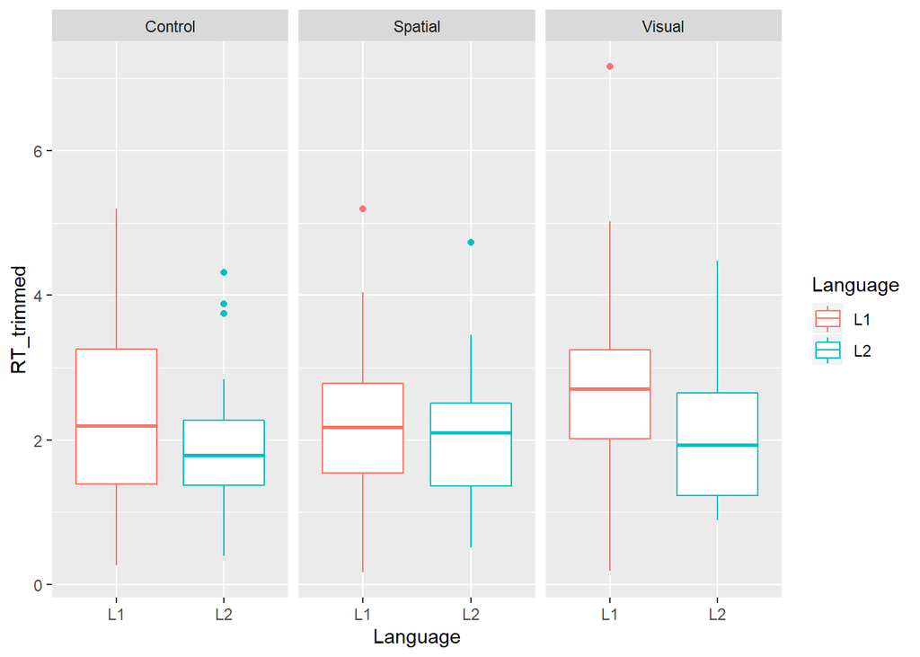

```r
ggplot(rt_subj, aes(x = Language, y = RT_trimmed, colour = Language)) +
  geom_boxplot() +
  facet_grid(. ~ Type)
```

Indeed, the data at least numerically show the expected tendency: The visual type of inferences were more demanding in the L1 than in the L2.

Perhaps a more insightful plot is one that is created by plotting per-cell means and 95% confidence intervals (assuming normality, i.e. +/- 2 SE).

```r
rt_subj_summ <- rt_subj %>%
  group_by(Language, Type) %>%
  summarise(M = mean(RT_trimmed), SE = sem_fun(RT_trimmed))
rt_subj_summ
```

```
## # A tibble: 6 x 4
## # Groups:   Language [2]
##   Language Type        M    SE
##   <fct>    <fct>   <dbl> <dbl>
## 1 L1       Control  2.34 0.241
## 2 L1       Spatial  2.24 0.212
## 3 L1       Visual   2.81 0.305
## 4 L2       Control  1.95 0.201
## 5 L2       Spatial  2.11 0.192
## 6 L2       Visual   2.05 0.192
```

First, just means and 95% confidence intervals:

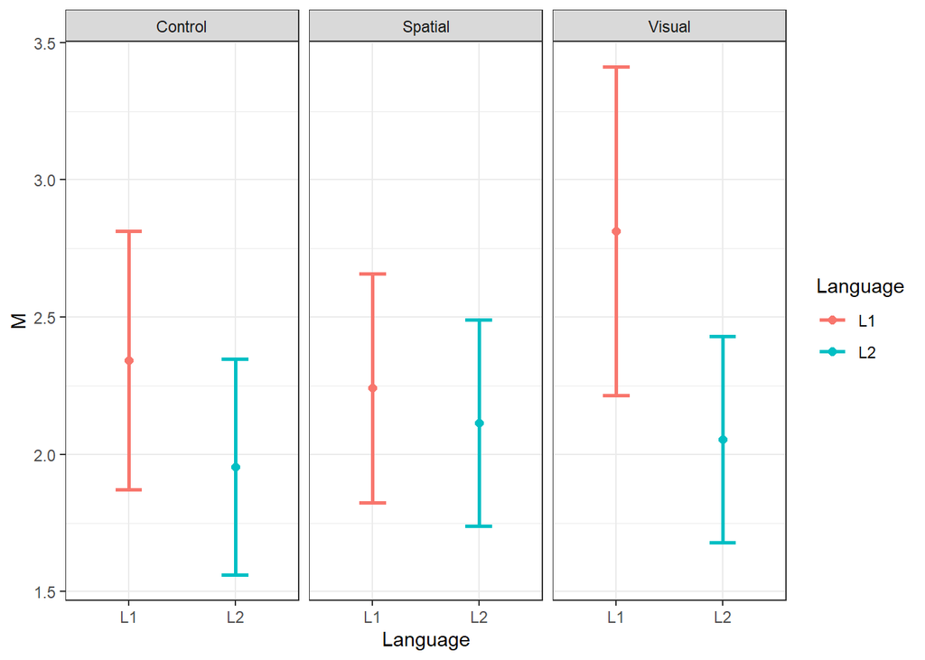

```r
ggplot(rt_subj_summ, aes(x = Language, y = M, colour = Language)) +
  geom_point(size = 2) +
  geom_errorbar(aes(ymin = M - 1.96 * SE, ymax = M + 1.96 * SE), width = .25,
                size = 1) +
  facet_grid(. ~ Type) +
  theme_bw()
```

But we can also overlay the individual subject means to get a better idea of the dispersion in the data.

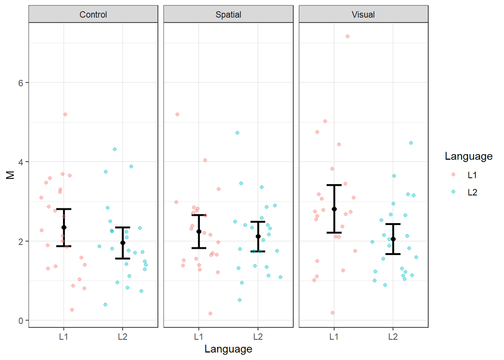

```r
ggplot(rt_subj_summ, aes(x = Language, y = M)) +
  geom_point(size = 2) +
  geom_errorbar(aes(ymin = M - 1.96 * SE, ymax = M + 1.96 * SE), width = .25,
                size = 1) +
  geom_jitter(data = rt_subj, aes(y = RT_trimmed, colour = Language), height = 0,
              alpha = .4) +
  facet_grid(. ~ Type) +
  theme_bw()
```

We can add a little bit more of information to the graph by connecting observations from the same speaker in the different languages. This basically shows individual by-subject slopes (as will later be captured by the random effects in linear mixed model, LMM).

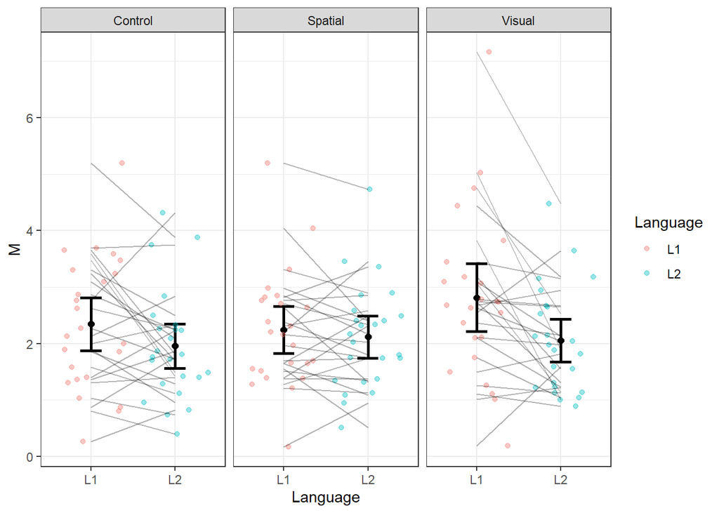

```r
ggplot(rt_subj_summ, aes(x = Language, y = M)) +
  geom_point(size = 2) +
  geom_errorbar(aes(ymin = M - 1.96 * SE, ymax = M + 1.96 * SE), width = .25,
                size = 1) +
  geom_jitter(data = rt_subj, aes(y = RT_trimmed, colour = Language), height = 0,
              alpha = .4) +
  geom_line(data = rt_subj, aes(y = RT_trimmed, group = Subject), alpha = .3) +
  facet_grid(. ~ Type) +
  theme_bw()
```

##### 5.2.9.2.2 LMM analysis

Appropriate coding for factors: see section *Inference Task > Response times > LMM analysis* above.

Run the models (or comment them as they take a long time)

```r
# # Model with critical interaction
# fm_RT_trimmed <- lmer(RT_trimmed ~ Language * Type +
#                 (1 + Language * Type | Subject) +
#                 (1 + Language * Type | InferPattern),
#               data = d_infe_corr, REML = FALSE)
# summary(fm_RT_trimmed)
# # Model WITHOUT critical interaction
# fm_RT_trimmed_nointeract <- lmer(RT_trimmed ~ Language + Type +
#                            (1 + Language * Type | Subject) +
#                            (1 + Language * Type | InferPattern),
#                          data = d_infe_corr, REML = FALSE)
# summary(fm_RT_trimmed_nointeract)
```

The interaction of Type and Language does not come out as significant in a LRT:

```r
# anova(fm_RT_trimmed, fm_RT_trimmed_nointeract)
```

```
> anova(fm_RT_trimmed, fm_RT_trimmed_nointeract)
Data: d_infe_corr
Models:
fm_RT_trimmed_nointeract: RT_trimmed ~ Language + Type + (1 + Language * Type | Subject) +
fm_RT_trimmed_nointeract:     (1 + Language * Type | InferPattern)
fm_RT_trimmed: RT_trimmed ~ Language * Type + (1 + Language * Type | Subject) +
fm_RT_trimmed:     (1 + Language * Type | InferPattern)
                         Df    AIC    BIC  logLik deviance  Chisq Chi Df Pr(>Chisq)
fm_RT_trimmed_nointeract 47 3491.6 3721.0 -1698.8   3397.6
fm_RT_trimmed            49 3491.9 3731.1 -1697.0   3393.9 3.6677      2     0.1598
```

Here’s the model output for the model with the interaction:

```
> summary(fm_RT_trimmed)
Linear mixed model fit by maximum likelihood  ['lmerMod']
Formula: RT_trimmed ~ Language * Type + (1 + Language * Type | Subject) +      (1 + Language * Type | InferPattern)
   Data: d_infe_corr

     AIC      BIC   logLik deviance df.resid
  3491.9   3731.1  -1697.0   3393.9      925

Scaled residuals:
    Min      1Q  Median      3Q     Max
-2.3635 -0.6018 -0.2069  0.3240  3.5815

Random effects:
 Groups       Name                                Variance Std.Dev. Corr
 Subject      (Intercept)                         0.735373 0.85754
              LanguageL2_vs_L1                    0.071684 0.26774  -0.51
              TypeSpat_vs_Cont                    0.060490 0.24595   0.13  0.16
              TypeVisual_vs_rest                  0.013906 0.11793  -0.36 -0.43 -0.61
              LanguageL2_vs_L1:TypeSpat_vs_Cont   0.031803 0.17833  -0.57  0.27 -0.86  0.51
              LanguageL2_vs_L1:TypeVisual_vs_rest 0.009635 0.09816   0.51 -0.90 -0.37  0.60 -0.09
 InferPattern (Intercept)                         0.010864 0.10423
              LanguageL2_vs_L1                    0.014260 0.11942   0.05
              TypeSpat_vs_Cont                    0.014847 0.12185   0.93 -0.32
              TypeVisual_vs_rest                  0.003268 0.05717  -0.89  0.40 -1.00
              LanguageL2_vs_L1:TypeSpat_vs_Cont   0.009561 0.09778  -0.93  0.31 -0.99  0.99
              LanguageL2_vs_L1:TypeVisual_vs_rest 0.001235 0.03515   0.50  0.79  0.19 -0.11 -0.24
 Residual                                         1.661521 1.28900
Number of obs: 974, groups:  Subject, 24; InferPattern, 8

Fixed effects:
                                    Estimate Std. Error t value
(Intercept)                          2.24023    0.18373  12.193
LanguageL2_vs_L1                    -0.20600    0.08072  -2.552
TypeSpat_vs_Cont                     0.13564    0.08366   1.621
TypeVisual_vs_rest                  -0.04467    0.04300  -1.039
LanguageL2_vs_L1:TypeSpat_vs_Cont   -0.07595    0.07168  -1.060
LanguageL2_vs_L1:TypeVisual_vs_rest  0.07021    0.03761   1.867

Correlation of Fixed Effects:
            (Intr) LnL2__L1 TyS__C TypV__ LL2__L1:TS
LnggL2_v_L1 -0.329
TypSpt_vs_C  0.168 -0.018
TypVsl_vs_r -0.276 -0.058   -0.446
LL2__L1:TS_ -0.367  0.167   -0.525  0.369
LL2__L1:TV_  0.296 -0.194   -0.086  0.159 -0.064
convergence code: 0
singular fit
```

While this way of analyzing the data results in a somewhat stronger coefficient estimate for the critical interaction, it still does not come out as statistically significant.